# Part I -Exploration de l'ensemble de données de Prêt

#### Question 15: Examinons maintenant la relation entre Interet, LoanStatus et la Duree du Prêt ?

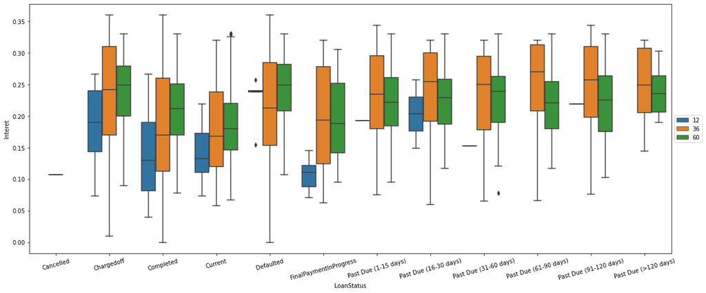

```python
# Création d'une boîte à moustaches pour les variables multivariées de BorrowerAPR, LoanStatus et Term avec le terme comme codage couleur
plt.figure(figsize=[20,8])
sb.boxplot(data = df, y = 'Interet', x = 'LoanStatus', hue = 'Duree')
plt.legend(loc = 6, bbox_to_anchor = (1.0, 0.5)) # legende de la figure
plt.xticks(rotation = 15);
```

#### Question 16: Examinons la relation entre le statut du prêt, le montant initial du prêt et le paiement mensuel du prêt pour voir s'il y a des informations à noter.

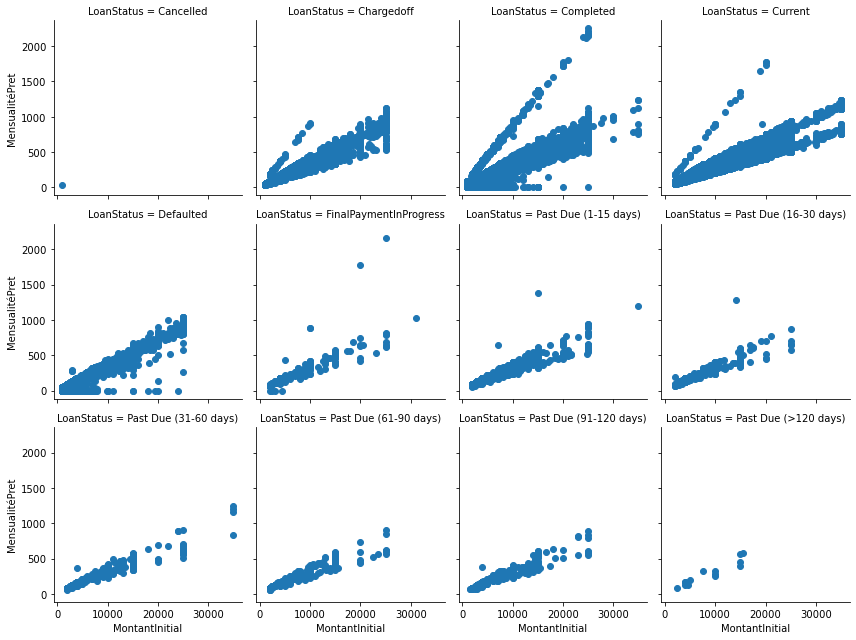

```python
# Création d'une grille de facettes pour les variables multivariées de loanStatus, MonthlyLoanPayment et LoanOriginalAmount
f = sb.FacetGrid(data=df, col='LoanStatus', col_wrap=4) #création de quatre colonnes à l'aide de LoanStatus par colonne
f.map(plt.scatter, 'MontantInitial', 'MensualitéPret'); #scatter plot
```

#### Observation

> Dans toutes les catégories de statut de prêt, on observe que plus le montant initial du prêt obtenu est élevé, plus les mensualités de prêt sont élevées, ce qui signifie une corrélation positive entre MonthlyLoanPayment et LoanOrginalAmount dans les différentes catégories de LoanStatus.